# 01 · Explore Data Quality

This optional enhancement notebook inspects the raw National Water Plan dataset before any cleaning happens. It mirrors the guidance in `docs/DEVELOPMENT_RECOMMENDATIONS.md` by focusing on the diagnostic steps that inform how `scripts/data-cleaner.py` should be configured.

## Notebook goals

- Understand baseline quality metrics (shape, missingness, duplicates)
- Inspect geographic coordinates to confirm valid ranges
- Review spill event coverage to surface outliers or data gaps
- Explore categorical health indicators for text-heavy columns

```python
from __future__ import annotations

from pathlib import Path
import importlib.util
import sys

import dask.dataframe as dd
import matplotlib.pyplot as plt
import pandas as pd
import seaborn as sns

plt.style.use("seaborn-v0_8")
sns.set_theme(context="notebook", style="ticks")
pd.set_option("display.max_columns", 40)
pd.set_option("display.precision", 2)

PROJECT_ROOT = Path.cwd().resolve().parents[1]
DATA_PATH = PROJECT_ROOT / "data" / "national_water_plan.csv"
SCRIPTS_DIR = PROJECT_ROOT / "scripts"


def load_module(module_name: str, file_path: Path):
    if module_name in sys.modules:
        return sys.modules[module_name]

    spec = importlib.util.spec_from_file_location(module_name, file_path)
    module = importlib.util.module_from_spec(spec)
    sys.modules[module_name] = module
    spec.loader.exec_module(module)
    return module


data_loader = load_module("project_data_loader", SCRIPTS_DIR / "data-loader.py")
DataLoader = data_loader.DataLoader
DataConfig = data_loader.DataConfig
ExplorationReport = data_loader.ExplorationReport

data_cleaner = load_module("project_data_cleaner", SCRIPTS_DIR / "data-cleaner.py")
WaterDataCleaner = data_cleaner.WaterDataCleaner
DataCleanerConfig = data_cleaner.DataCleanerConfig
```

[output not shown]

[output not shown]

[output not shown]

## 1. Load raw dataset with the production loader

The `DataLoader` handles schema validation, dtype optimization, and produces the same `ExplorationReport` structure the cleaning pipeline expects. Keeping the exploratory view aligned with production logic makes it easier to cross-reference findings.

```python
data_config = DataConfig(filepath=str(DATA_PATH))
loader = DataLoader(data_config)
raw_ddf, exploration_report = loader.load_and_explore_data()

raw_preview = raw_ddf.head(5)
raw_preview
```

[output not shown]

[output not shown]

[output not shown]

```
Duplicate check skipped (not supported for this operation)
```

```
High missing data percentage: 8.10%
```

|  | ID | Water company | Site name | Longitude | Latitude | Receiving Environment | River Basin District | Management Catchment | Local Authority | Water Body | Bathing Water Discharge Flag | Shellfish Water Discharge Flag | Ecological High Priority Site Flag | Marine Protected Area Discharge Flag | Non-bathing Priority Site Flag | Spill Events 2020 | Spill Events 2021 | Spill Events 2022 | Sewage Reduction Plan Targets Met Flag | Spill Improvement Date Planned | Rainfall Improvement Target Delivery Flag | Improvements List | Predicted Annual Spill Frequence Post Scheme | Baseline | Baseline Less Than Target | Requires No Improvement | Meets 2025 Requirements | Meets 2030 Requirements | Meets 2035 Requirements | … |
| --- | --- | --- | --- | --- | --- | --- | --- | --- | --- | --- | --- | --- | --- | --- | --- | --- | --- | --- | --- | --- | --- | --- | --- | --- | --- | --- | --- | --- | --- | --- |
| 0 | AnW0001 | Anglian Water | ABTHORPE TERMINAL PUMPING STATION | -1.06 | 52.11 | Inland | Anglian | Upper and Bedford Ouse | West Northamptonshire | Tove (US Greens Norton) | N | N | N | N | <NA> | NaN | NaN | NaN | Y | 2023.0 | <NA> | Operational (e.g. blockages). Other improvemen... | 10.0 | NaN | <NA> | Y | 1.0 | 1.0 | 1.0 | … |
| 1 | AnW0002 | Anglian Water | SCHOOL LANE SPS ABY | 0.12 | 53.28 | Inland | Anglian | Witham | East Lindsey | Woldgrift Drain | N | N | N | N | <NA> | NaN | NaN | NaN | N | 2045.0 | <NA> | Operational (e.g. blockages). Other improvemen... | 10.0 | NaN | <NA> | <NA> | 0.0 | 0.0 | 0.0 | … |
| 2 | AnW0003 | Anglian Water | AKELEY (EX STW) PS | -0.97 | 52.04 | Inland | Anglian | Upper and Bedford Ouse | Buckinghamshire | Leckhampstead Brook | N | N | N | N | <NA> | 18.0 | 51.0 | 25.0 | N | 2035.0 | <NA> | Sealing of sewers, Operational (e.g. blockages... | 10.0 | 18.0 | <NA> | <NA> | 0.0 | 0.0 | 1.0 | … |
| 3 | AnW0004 | Anglian Water | ALDBOROUGH WATER RECYCLING CENTRE | 1.25 | 52.86 | Inland | Anglian | Broadland Rivers | North Norfolk | Scarrow Beck | N | N | N | N | <NA> | NaN | 2.0 | 4.0 | Y | 2023.0 | <NA> | Storage. Other improvements to be confirmed | 10.0 | 3.0 | Y | Y | 1.0 | 1.0 | 1.0 | … |
| 4 | AnW0005 | Anglian Water | ALDEBURGH STW | 1.61 | 52.14 | Coastal | Anglian | Coastal, Suffolk | East Suffolk | Suffolk | N | N | N | N | <NA> | NaN | 7.0 | 65.0 | N | 2040.0 | <NA> | Improvements to be confirmed | 10.0 | 36.0 | <NA> | <NA> | 0.0 | 0.0 | 0.0 | … |

### Baseline metadata

Use the exploration report to understand the big-picture dimensions and high-level warnings before diving into column-level diagnostics.

```python
metadata = exploration_report.metadata
print(
    f"Rows: {metadata.rows:,}\n"
    f"Columns: {metadata.columns}\n"
    f"Memory (MB): {metadata.memory_usage:.2f}\n"
    f"Missing (%): {metadata.missing_values_percent:.2f}\n"
    f"Duplicate rows: {metadata.duplicate_rows:,}"
)

pd.DataFrame(
    {
        "type": ["errors", "warnings"],
        "messages": [exploration_report.errors, exploration_report.warnings],
    }
)
```

```
Rows: 14,187
Columns: 38
Memory (MB): 5.87
Missing (%): 8.10
Duplicate rows: 0
```

|  | type | messages |
| --- | --- | --- |
| 0 | errors | [] |
| 1 | warnings | [Duplicate check skipped (not supported for th... |

### Create a manageable in-memory sample

Large Dask frames are great for scale, but plotting and quick profiling is smoother with a pandas sample. Adjust `SAMPLE_ROWS` if you want a deeper slice.

```python
SAMPLE_ROWS = 10_000
sample_pdf = raw_ddf.head(SAMPLE_ROWS, compute=True)

print(f"Sample rows: {len(sample_pdf):,} (first partitions only)")
sample_pdf.describe(include="all").transpose().head(10)
```

```
Sample rows: 10,000 (first partitions only)
```

|  | count | unique | top | freq | mean | std | min | 25% | 50% | 75% | max |
| --- | --- | --- | --- | --- | --- | --- | --- | --- | --- | --- | --- |
| ID | 10000 | 10000 | AnW0001 | 1 | NaN | NaN | NaN | NaN | NaN | NaN | NaN |
| Water company | 10000 | 7 | Severn Trent | 2466 | NaN | NaN | NaN | NaN | NaN | NaN | NaN |
| Site name | 9734 | 9017 | SOUTHEND - BELTON GARDENS PS | 27 | NaN | NaN | NaN | NaN | NaN | NaN | NaN |
| Longitude | 10000.0 | NaN | NaN | NaN | -1.64 | 1.41 | -6.34 | -2.38 | -1.61 | -0.85 | 1.76 |
| Latitude | 10000.0 | NaN | NaN | NaN | 52.63 | 1.41 | 49.92 | 51.47 | 52.6 | 53.5 | 55.79 |
| Receiving Environment | 10000 | 3 | Inland | 8395 | NaN | NaN | NaN | NaN | NaN | NaN | NaN |
| River Basin District | 10000 | 10 | Humber | 1894 | NaN | NaN | NaN | NaN | NaN | NaN | NaN |
| Management Catchment | 10000 | 185 | Tame Anker and Mease | 524 | NaN | NaN | NaN | NaN | NaN | NaN | NaN |
| Local Authority | 10000 | 270 | County Durham | 541 | NaN | NaN | NaN | NaN | NaN | NaN | NaN |
| Water Body | 10000 | 1927 | Not part of a river WB catchment | 1232 | NaN | NaN | NaN | NaN | NaN | NaN | NaN |

## 2. Missing values and duplicates

Quantify missingness for critical fields to prioritize cleaning rules. The `DataCleanerConfig` uses these same column lists as guardrails.

```python
base_config = DataCleanerConfig()
key_columns = [col for col in sorted(set(base_config.required_columns + base_config.optional_columns)) if col in raw_ddf.columns]

missing_counts = (
    raw_ddf[key_columns]
    .isnull()
    .sum()
    .compute()
    .astype(int)
)

missing_df = (
    pd.DataFrame({"missing": missing_counts})
    .assign(percent=lambda df: (df["missing"] / metadata.rows) * 100)
    .sort_values("percent", ascending=False)
)

duplicate_series = raw_ddf.map_partitions(
    lambda part: pd.Series({"duplicates": int(part.duplicated().sum())}),
    meta=pd.Series(dtype="int64", name="duplicates"),
)
duplicate_count = int(duplicate_series.sum().compute())

print(f"Duplicate rows detected: {duplicate_count:,}")
missing_df.head(10)
```

```
Duplicate rows detected: 0
```

|  | missing | percent |
| --- | --- | --- |
| Latitude | 0 | 0.0 |
| Longitude | 0 | 0.0 |
| Receiving Environment | 0 | 0.0 |
| River Basin District | 0 | 0.0 |
| Water company | 0 | 0.0 |

[figure not shown]

```python
fig, ax = plt.subplots(figsize=(10, 5))
(
    missing_df.head(12)[::-1]
    .plot(kind="barh", y="percent", legend=False, ax=ax, color="#3182bd")
)
ax.set_xlabel("Missing (%)")
ax.set_ylabel("Column")
ax.set_title("Top missing columns (raw data)")
plt.tight_layout()
plt.show()
```

## 3. Geographic coordinate diagnostics

Latitude/longitude validation removes invalid locations. Plotting a quick scatter exposes obvious geographic outliers before defining stricter bounds.

```python
coord_cols = [col for col in ["Latitude", "Longitude"] if col in raw_ddf.columns]
coord_summary = (
    raw_ddf[coord_cols]
    .describe(percentiles=[0.25, 0.5, 0.75])
    .compute()
    .loc[["count", "min", "max", "mean", "std"]]
)

lat_range = (base_config.lat_min, base_config.lat_max)
lon_range = (base_config.lon_min, base_config.lon_max)

invalid_lat = (
    (~raw_ddf["Latitude"].between(lat_range[0], lat_range[1]))
    .sum()
    .compute()
    if "Latitude" in raw_ddf.columns
    else 0
)
invalid_lon = (
    (~raw_ddf["Longitude"].between(lon_range[0], lon_range[1]))
    .sum()
    .compute()
    if "Longitude" in raw_ddf.columns
    else 0
)

pd.DataFrame(
    {
        "metric": ["latitude", "longitude"],
        "invalid_rows": [invalid_lat, invalid_lon],
        "min_config": [lat_range[0], lon_range[0]],
        "max_config": [lat_range[1], lon_range[1]],
    }
), coord_summary
```

```
(      metric  invalid_rows  min_config  max_config
 0   latitude             0       -90.0        90.0
 1  longitude             0      -180.0       180.0,
        Latitude  Longitude
 count  14187.00   14187.00
 min       49.92      -6.34
 max       55.79       1.76
 mean      52.73      -1.73
 std        1.38       1.25)
```

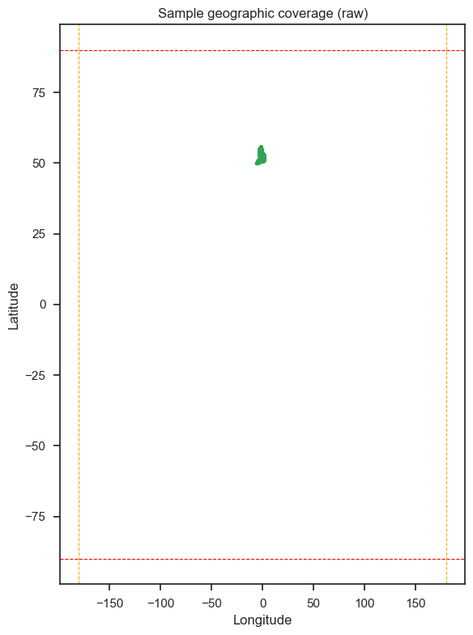

```python
geo_sample = sample_pdf.dropna(subset=coord_cols)
fig, ax = plt.subplots(figsize=(6, 8))
ax.scatter(
    geo_sample["Longitude"],
    geo_sample["Latitude"],
    s=10,
    alpha=0.4,
    linewidths=0,
    color="#31a354",
)
ax.set_title("Sample geographic coverage (raw)")
ax.set_xlabel("Longitude")
ax.set_ylabel("Latitude")
ax.axhline(lat_range[0], color="red", linestyle="--", linewidth=0.8)
ax.axhline(lat_range[1], color="red", linestyle="--", linewidth=0.8)
ax.axvline(lon_range[0], color="orange", linestyle="--", linewidth=0.8)
ax.axvline(lon_range[1], color="orange", linestyle="--", linewidth=0.8)
plt.tight_layout()
plt.show()
```

## 4. Spill event coverage

These columns often drive downstream analytics. Understanding missingness and value spread makes it easier to tune outlier handling and the `min_valid_spill_years` rule.

```python
spill_cols = [col for col in base_config.spill_year_columns if col in raw_ddf.columns]

spill_stats = (
    raw_ddf[spill_cols]
    .describe(percentiles=[0.5, 0.75, 0.9])
    .compute()
    .loc[["count", "mean", "std", "min", "50%", "75%", "90%", "max"]]
    .transpose()
    .rename(columns={"50%": "median"})
)

missing_spill = (
    raw_ddf[spill_cols]
    .isnull()
    .sum()
    .compute()
)

spill_stats = spill_stats.assign(
    missing=missing_spill,
    missing_pct=lambda df: (df["missing"] / metadata.rows) * 100,
)

spill_stats.head()
```

|  | count | mean | std | min | median | 75% | 90% | max | missing | missing_pct |
| --- | --- | --- | --- | --- | --- | --- | --- | --- | --- | --- |
| Spill Events 2020 | 11603.0 | 33.71 | 45.37 | 0.0 | 17.0 | 47.0 | 90.0 | 378.0 | 2584 | 18.21 |
| Spill Events 2021 | 12399.0 | 29.53 | 37.64 | 0.0 | 16.0 | 43.0 | 77.0 | 361.0 | 1788 | 12.60 |
| Spill Events 2022 | 13231.0 | 22.52 | 30.74 | 0.0 | 11.0 | 33.0 | 61.0 | 364.0 | 956 | 6.74 |

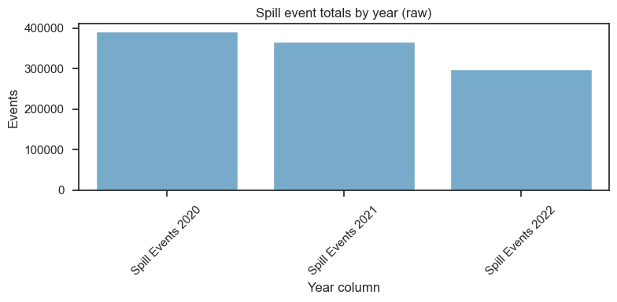

```python
yearly_totals = (
    raw_ddf[spill_cols]
    .sum()
    .compute()
    .reset_index()
    .rename(columns={"index": "year", 0: "total_events"})
)

fig, ax = plt.subplots(figsize=(8, 4))
sns.barplot(
    data=yearly_totals,
    x="year",
    y="total_events",
    color="#6baed6",
    ax=ax,
)
ax.set_title("Spill event totals by year (raw)")
ax.set_xlabel("Year column")
ax.set_ylabel("Events")
plt.xticks(rotation=45)
plt.tight_layout()
plt.show()
```

## 5. Text field health check

Whitespace trimming plus emptiness checks remove rows that lack contextual metadata. Review the dominant values to confirm expectations.

```python
text_cols = [col for col in base_config.text_columns if col in sample_pdf.columns]
text_summary = []

for col in text_cols:
    series = sample_pdf[col].astype(str).str.strip()
    series = series.replace({"": pd.NA, "nan": pd.NA})
    missing = series.isna().sum()
    top_value = series.mode().iloc[0] if not series.mode().empty else None
    top_freq = int((series == top_value).sum()) if top_value else 0
    text_summary.append(
        {
            "column": col,
            "missing_pct": missing / len(series) * 100,
            "unique": series.nunique(dropna=True),
            "top_value": top_value,
            "top_freq": top_freq,
        }
    )

pd.DataFrame(text_summary).sort_values("missing_pct", ascending=False)
```

|  | column | missing_pct | unique | top_value | top_freq |
| --- | --- | --- | --- | --- | --- |
| 0 | Water company | 0.0 | 7 | Severn Trent | 2466 |
| 1 | River Basin District | 0.0 | 10 | Humber | 1894 |
| 2 | Receiving Environment | 0.0 | 3 | Inland | 8395 |

## Takeaways

- Feed the missing value table into `DataCleanerConfig` thresholds (`missing_value_threshold`, `min_valid_spill_years`).
- Adjust coordinate ranges before running the pipeline if geographic outliers look legitimate.
- Use the spill event totals to calibrate outlier handling (`outlier_std_threshold`).
- Keep the text frequency table handy when reviewing rows that get dropped for empty metadata.